# Penalization in dynamicLM Example

Anya Fries

# 1 Load libraries & data

**TO DO before running this file:**

The file is meant to be run using `dynamicLM` on the branch `extension/regularisation`. I.e., the following should be run before using this file:

- `git clone https://github.com/thehanlab/dynamicLM.git`
- `cd dynamicLM`
- `git checkout extension/regularisation`

Then paste the folder `example_code` (containing this file and the data) anywhere inside the folder `dynamicLM`. To use the code without knitting, one can also jsut call `devtools::load_all()` in the console (instead of manually loading the library).

```r
library(survival)
#### manually load library
prefix <- "../R/"

files <- c("addLMtime.R", "checks.R", "cutLMsuper.R", "cv.penLM.R", "fitLM.R", "LMcalPlot.R", "LMScore.R", "penLM.R", "plot.R", "predLMrisk.R", "print.R", "riskScore.R", "utils.R")
for (f in files){
  source(paste0(prefix,f))
}
####

#### To load Gensheimer's simulated data
source("load_gensheimer_data.R")
####
```

# 2 Load data

```r
tmp <- get_simulated_data()
DAT <- tmp$df
x_cols <- tmp$x_cols

DAT[1,]
```

[output not shown]

[output cut: 71 more lines]

[output not shown]

# 3 Super dataset

```r
landmark_gap <- 365/2
LMs <- seq(0,365,landmark_gap)
t_hor <- 365*5
outcome = list(time="time", status="status")
covars = list(fixed=x_cols, varying=NULL)
```

Typical `dynamicLM` dataset:

```r
LMdata = cutLMsuper(DAT, outcome, LMs, t_hor, covars,  format="long", id="id", rtime="visit")
```

Alternate data format (more typical when considering `glmnet`):

- `x`: matrix of covariates
- `y`: `Surv` object, the outcome

```r
x = as.matrix(LMdata$LMdata[x_cols])
y = Surv(LMdata$LMdata$LM, LMdata$LMdata$time, LMdata$LMdata$status)
```

# 4 Fit a path

## 4.1 Without cross-validation

Both data inputs give the same path, which can be printed and plotted

```r
path = penLM(x, y)
```

```r
path = penLM(LMdata, x_cols)
```

```r
print(path)
```

```
##
## Penalized landmark Cox super model fit for dynamic prediction:
##
##
## Call:  glmnet::glmnet(x = x, y = yi, family = "cox", alpha = alpha,      ID_col = ..1)
##
##     Df %Dev   Lambda
## 1    0 0.00 0.189900
## 2    1 0.21 0.173000
## 3    1 0.36 0.157700
## 4    1 0.48 0.143700
## 5    1 0.58 0.130900
## 6    1 0.65 0.119300
## 7    1 0.71 0.108700
## 8    1 0.76 0.099020
```

[output cut: 58 more lines]

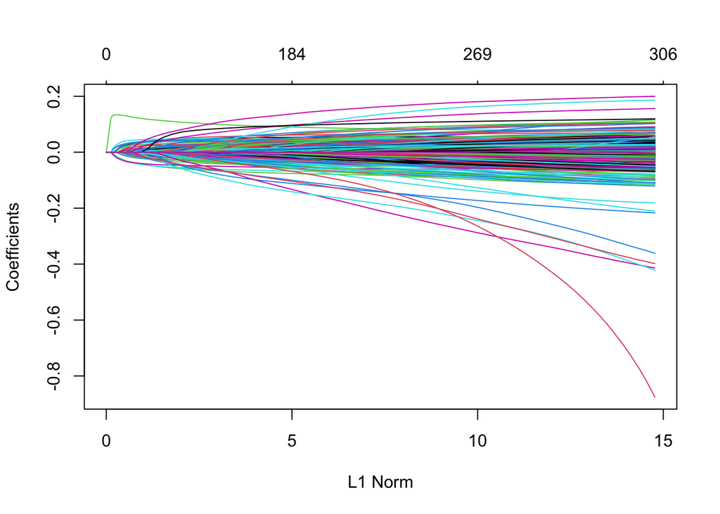

```r
plot(path)
```

## 4.2 With cross-validation

Both data inputs give the same path, which can be printed and plotted

```r
cv.path = cv.penLM(x, y)
```

```r
cv.path = cv.penLM(LMdata, x_cols)
```

```r
print(cv.path)
```

```
##
## Cross-validated penalized landmark Cox super model fit for dynamic prediction:
##
##
## Call:  glmnet::cv.glmnet(x = x, y = yi, type.measure = type.measure,      foldid = foldid, family = "cox", alpha = alpha)
##
## Measure: Partial Likelihood Deviance
##
##      Lambda Index Measure     SE Nonzero
## min 0.02692    22   12.11 0.1222      84
## 1se 0.07491    11   12.22 0.1101      10
```

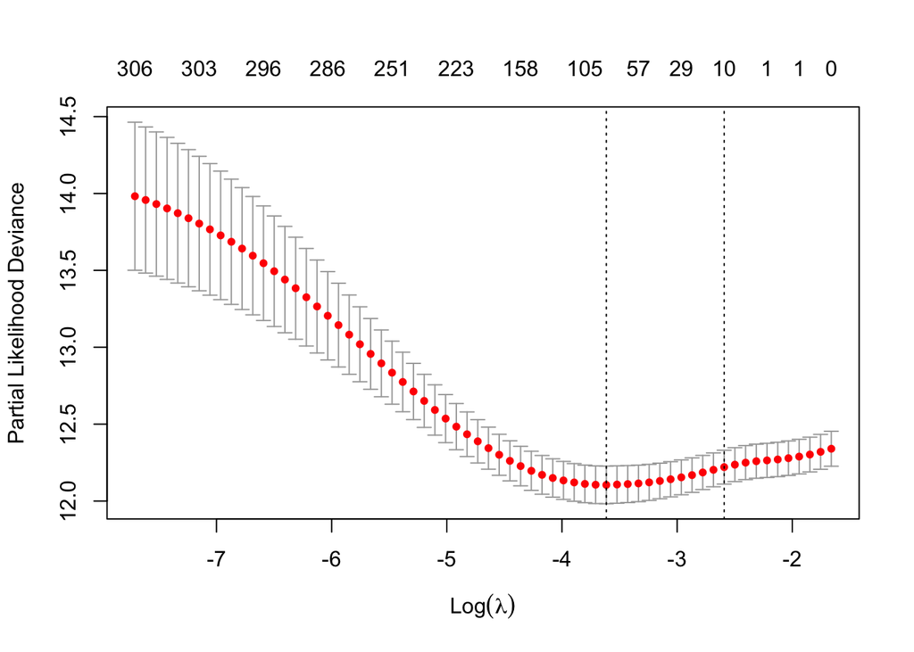

```r
plot(cv.path)
```

# 5 Fit a model from the path

For now, fitting a model can only be done when the path was fit using `LMdata` and `x_cols`. Using `x` and `y` will still be implemented, with additional arguments.

## 5.1 Without cross-validation

Choice of lambda is done numerically.

```r
model1 = fitLM(path, lambda=0.08)
```

## 5.2 With cross-validation

Three options: numeric input, `lambda.min` (the lambda that minimises the CV loss) or `lambda.1se` (the value of lambda that gives the most regularized model (largest lambda) such that the cross-validated error is within one standard error of the minimum)

```r
model_num = fitLM(cv.path, lambda=0.08)
model_min = fitLM(cv.path, lambda="lambda.min")
model_1se = fitLM(cv.path, lambda="lambda.1se")
```

One can print the model

```r
print(model_1se)
```

```
##
## Penalized landmark Cox super model fit for dynamic prediction of window size 1825 (lambda = 0.0749076409262347):
##
##                coef exp(coef)
## text9   0.001975996 1.0019779
## text12  0.016378335 1.0165132
## text13  0.134122171 1.1435325
## text17  0.004005279 1.0040133
## text37 -0.011501023 0.9885649
## text39 -0.013812175 0.9862828
## text52 -0.016426952 0.9837072
## text56  0.017111294 1.0172585
## text92  0.005468559 1.0054835
## text99  0.023127954 1.0233975
```

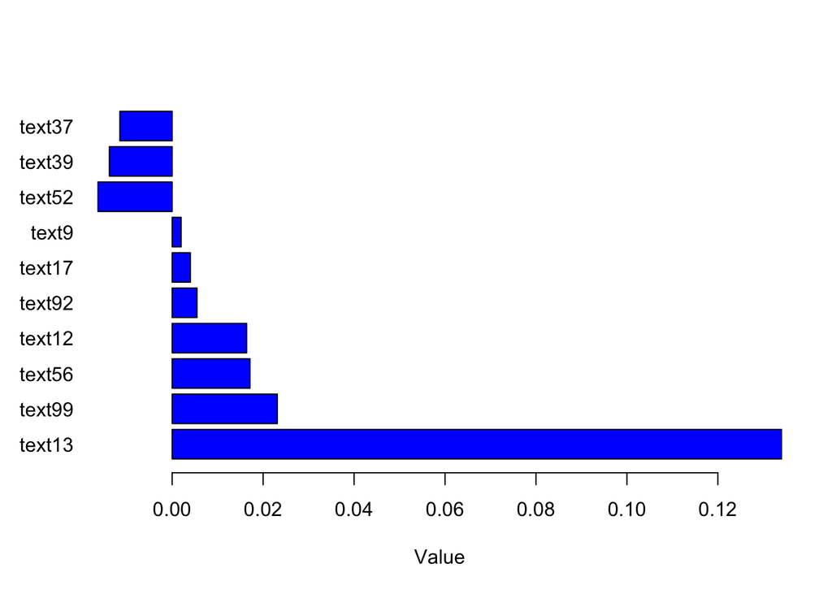

```r
plot(model_1se, single.plot = T, max_coefs = NULL)
```